# STAT/MATH 495: Problem Set 07

MERON GEDRAGO

2017-10-24

Information on the competition can be found [here](https://www.kaggle.com/c/GiveMeSomeCredit/data).

# Collaboration

Please indicate who you collaborated with on this assignment:

# Build binary classifier

Build the binary classifier based on a single predictor variable: `DebtRatio`, `age`, or `MonthlyIncome`. Justify this choice.

I decided to look at the correlation matrix to decide which variable to take as a predictor variable. The correlation of DebtRatio`,`age`, or`MonthlyIncome` with ‘SeriousDlqin2yrs’ is as follows -0.003291309,-0.102684838 and -0.019745547 respectively. As we can see, ‘age’ is the most correlated with ‘SeriousDlqin2yrs’ out of the three so we choose ‘age’ to be our predictor variable.

# ROC curve

Based on the ultimate classifier you choose, plot a corresponding ROC curve.

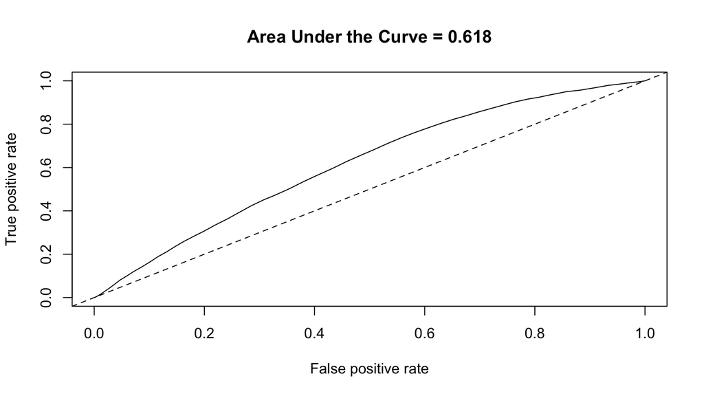

```r
#plotting the ROC curve
plot(perf, main=paste("Area Under the Curve =", round(auc, 3)))
abline(c(0, 1), lty=2)
```

# ROC curve for random guessing

Instead of using any predictor information as you did above, switch your predictions to random guesses and plot the resulting ROC curve.

The below ROC curve shows a straight diagonal line across the specificity vs the sensitivity of the graph. This means that the area under the curve is 0.5 and the model is useless to us.

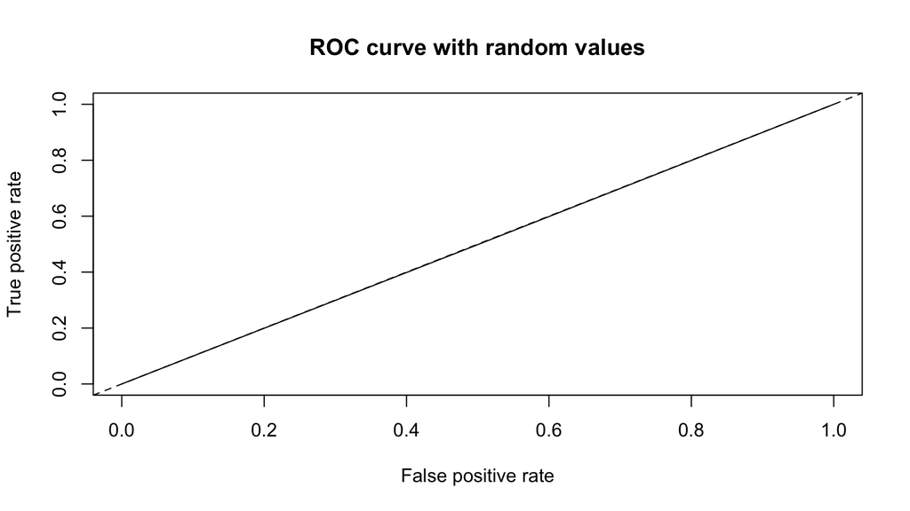

```r
#plotting the ROC curve
plot(perf, main=paste("ROC curve with random values"))
abline(c(0, 1), lty=2)
```